# Lecture 8: Summarizing Data Part 2: Plots

Nick Huntington-Klein

January 29, 2019

## Recap

- Summary statistics are ways of describing the *distribution* of a variable
- Examples include mean, percentiles, SD, and specific percentiles of interest (median, min, max)
- Another, very good way to describe a variable is by actually showing that distribution with a graph
- I showed you plenty of graphs last time, this time I’m going to show you how to make them yourself!

## Note about ggplot

- As I mentioned before, we’re going straightforward, doing our plotting with base R
- In the case of plotting, it’s going to be easier to use base R, but also not look as good as the alternative, `ggplot2`, which is also in the tidyverse package.
- `ggplot2` code for plots will be available in the slides. Just search for ‘ggplot’
- And have also been for most previous slides - I’ve been making most graphs with it!
- Don’t forget extra credit opportunity for learning `ggplot2`

## Plot types we will cover:

- Density plots (for continuous)
- Histograms (for continuous)
- Box plots (for continuous)
- Bar plots (for categorical)
- Plus:
  - Adding plots together
  - Putting lines on plots
  - Makin ’em look good!

## Plots we won’t:

- Lots and lots and lots of plot options
- Mosaics, Sankey plots, pie graphs
- Some aren’t common in Econ but could be!
- Others are just too tricky (like *maps*)
- See [The R Graph Gallery](https://www.r-graph-gallery.com/)

## Density plots and histograms

- Density plots and histograms will show you the full distribution of the variable
- Values along the x-axis, and how often those values show up on y
- The difference - density plots will present a smooth line by averaging nearby values
- A histogram will create “bins” and tell you how many observations fall into each
- (don’t forget we can save plots using Export in the Plots pane)

## Density plots

- To make a density plot, we take our variable and make a `density()` object out of it, then `plot()` that thing!
- Let’s play around with data from the `Ecdat` package

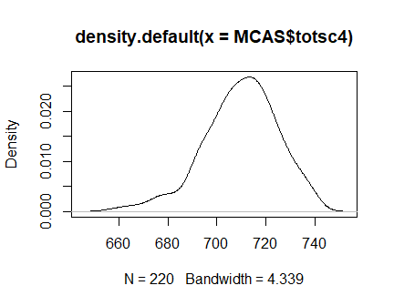

```r
install.packages('Ecdat')
library(Ecdat)
data(MCAS)
plot(density(MCAS$totsc4))
```

## Titles and labels

- Readability is super important in graphs
- Add labels and titles! Titles with ‘main’ and axis labels with ‘xlab’ and ‘ylab’

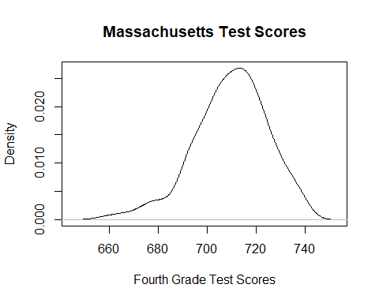

```r
plot(density(MCAS$totsc4),main='Massachusetts Test Scores',
     xlab='Fourth Grade Test Scores')
```

## Histograms

- Histograms require a little less typing - just `hist()`

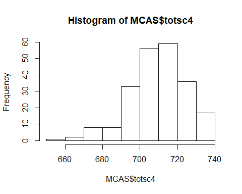

```r
hist(MCAS$totsc4)
```

## Histograms

- These need labels too! Other important options:
- Do proportions with `freq=FALSE`, or change how many bins there are, or where they are, with `breaks`

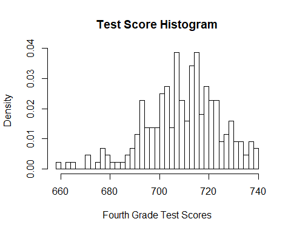

```r
hist(MCAS$totsc4,xlab="Fourth Grade Test Scores",
     main="Test Score Histogram",freq=FALSE,breaks=50)
```

## Box plots

- Less common in economics, but a good way to look at your data
- And check for outliers!
- Basically a summary table in graph form
- Shows the 25%, 50%, 75% percentiles
- Plus lines that represent 1.5 IQR (75th minus 25th)
- And dots for anything otuside that range

## Box plots

- Simple!
- Note the negative outliers - not necessarily a problem but good to know!

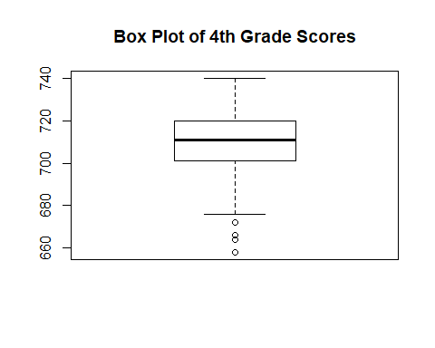

```r
boxplot(MCAS$totsc4,main="Box Plot of 4th Grade Scores")
```

## Box plots

- Easy to look at multiple variables at once, too

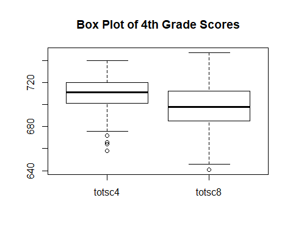

```r
boxplot(select(MCAS,totsc4,totsc8),main="Box Plot of 4th Grade Scores")
```

## Bar plots

- Last time we talked about the `table()` command, which shows us the whole distribution of a *categorical* variable
- Still a great command! Let’s look at majors of students taking advanced micro from a mid-1980s sample in the `Ecdat` package

```r
data(Mathlevel)
table(Mathlevel$major)
```

```
##
## other   eco   oss    ns   hum
##   130   209   103   126    41
```

## Bar plots

- Bar plots, express this table, graphically
- Stick that table in there!

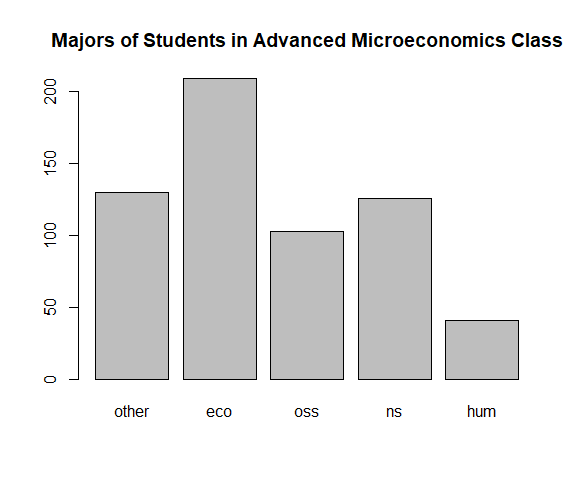

```r
barplot(table(Mathlevel$major),main="Majors of Students in Advanced Microeconomics Class")
```

## Bar plots

- And, just like before, we can make it a proportion instead of a count by wrapping that `table()` in `prop.table()`

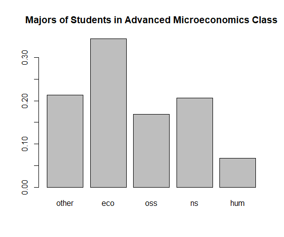

```r
barplot(prop.table(table(Mathlevel$major)),main="Majors of Students in Advanced Microeconomics Class")
```

## Adding Lines

- It’s pretty common for us to want to add some explanatory lines to our graphs
- For example, adding mean/median/etc. to a density
- Or showing where 0 is
- We can do this with `abline()` which adds a line with a given intercept (a) and slope (b), after we make our plot.

## Adding Lines

- After creating the plot, THEN add the `abline(intercept,slope)`, or `abline(h=horizontal)`, `abline(v=vertical)` for horizontal or vertical numbers

```r
hist(MCAS$totsc4)
passingscore <- 705
abline(0,1)
abline(v=passingscore,col='red')
abline(h=50)
```

## Adding Lines

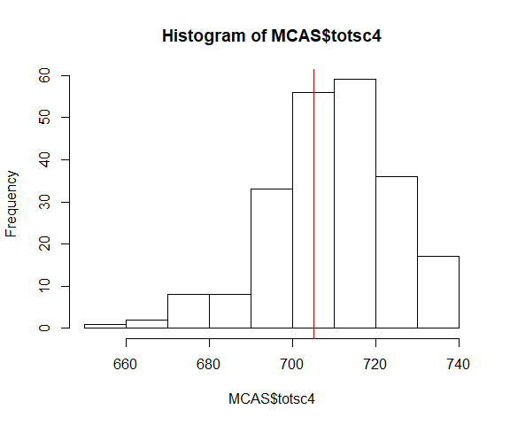

```r
hist(MCAS$totsc4)
passingscore <- 705
abline(v=passingscore,col='red')
```

## Adding Lines

- A common use of adding lines is to show where the mean or median of the distribution is, as I did in the last lecture

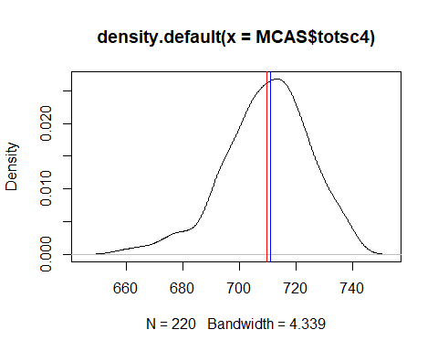

```r
plot(density(MCAS$totsc4))
abline(v=mean(MCAS$totsc4),col='red')
abline(v=median(MCAS$totsc4),col='blue')
```

## Overlaying Densities

- Sometimes it’s nice to be able to compare two distributions
- Because density plots are so simple, we can do this by overlaying them
- The `lines()` function will, like `abline()`, add a line to your graph
- But it can do this with a density! Be sure to set colors so you can tell them apart

## Overlaying Densities

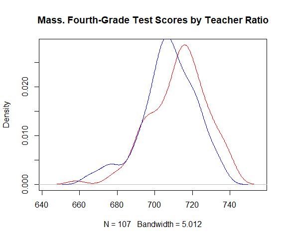

```r
plot(density(filter(MCAS,tchratio < median(tchratio))$totsc4),
     col='red',main="Mass. Fourth-Grade Test Scores by Teacher Ratio")
lines(density(filter(MCAS,tchratio >= median(tchratio))$totsc4),col='blue')
```

## Practice

- Install `Ecdata`, load it, and get the `MCAS` data
- Make a density plot for `totsc4`, and add a vertical green dashed (tough!) line at the median
- Create a bar plot showing the *proportion* of observations that have nonzero values of `bilingua`
- Create a box plot for totday, and add a horizontal line at the mean
- Go back and add appropriate titles and/or axis labels to all graphs

## Practice answers

```r
install.packages('Ecdata')
library(Ecdata)
data(MCAS)
plot(density(MCAS$totsc4),xlab="4th Grade Test Score")
abline(v=median(MCAS$totsc4),col='green',lty='dashed')

MCAS <- MCAS %>% mutate(nonzerobi = bilingua > 0)
barplot(prop.table(table(MCAS$nonzerobi)),main="Nonzero Spending Per Bilingual Student")

boxplot(MCAS$totday,main="Spending Per Pupil")
abline(h=mean(MCAS$totday))
```